**Deep Learning for Mechanical Engineering**  
**Final Exam**  
**December 21th 2022, 8:00 PM to 10:00 PM (120 minutes)**

TA: Jaejung Park  
Instructor: Prof. Seungchul Lee  
http://iai.postech.ac.kr/  
Industrial AI Lab at POSTECH

# Problem 1: CAE (Anomaly Detection) & FCN with Skip Connections

In this problem, you will use CAE to find the anomalous dataset with defects. After finding the defected anomalous dataset, you will use FCN to fix the defected dataset. After fixing the defected dataset, you will check whether your FCN has fixed the dataset with good performance with CAE. Note that all train and test dataset are MNIST image of digit '1'.

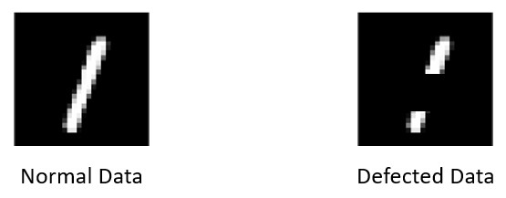

- [AD Training dataset](https://www.dropbox.com/s/n9sr9oq8bghd53q/AD%20train%20data.npy?dl=1)
- [AD Test dataset 1](https://www.dropbox.com/s/3sp3fzk8yi7fahc/AD%20test%20data%201.npy?dl=1)
- [AD Test dataset 2](https://www.dropbox.com/s/r6ac5azdvcovx38/AD%20test%20data%202.npy?dl=1)
- [AD Test dataset 3](https://www.dropbox.com/s/ge41nyb2hf8ls9l/AD%20test%20data%203.npy?dl=1)

### (1) Build CAE model for anomaly detection

```python
import matplotlib.pyplot as plt
import tensorflow as tf
import numpy as np
import random
from sklearn.model_selection import train_test_split
```

```python
train = np.load('./data_files/AD train data.npy')
```

```python
encoder = tf.keras.models.Sequential([
    tf.keras.layers.Conv2D(filters = 32,
                           kernel_size = (3,3),
                           strides = (2,2),
                           activation = 'relu',
                           padding = 'SAME',
                           input_shape = (28, 28, 1)),

    tf.keras.layers.Conv2D(filters = 64,
                           kernel_size = (3,3),
                           strides = (2,2),
                           activation = 'relu',
                           padding = 'SAME',
                           input_shape = (14, 14, 32)),

    tf.keras.layers.Conv2D(filters = 2,
                           kernel_size = (7,7),
                           padding = 'VALID',
                           input_shape = (7, 7, 64))
])

encoder.summary()
```

```
Model: "sequential"
_________________________________________________________________
Layer (type)                 Output Shape              Param #
=================================================================
conv2d (Conv2D)              (None, 14, 14, 32)        320
_________________________________________________________________
conv2d_1 (Conv2D)            (None, 7, 7, 64)          18496
_________________________________________________________________
conv2d_2 (Conv2D)            (None, 1, 1, 2)           6274
=================================================================
Total params: 25,090
Trainable params: 25,090
Non-trainable params: 0
_________________________________________________________________
```

```python
decoder = tf.keras.models.Sequential([
    tf.keras.layers.Conv2DTranspose(filters = 64,
                                    kernel_size = (7,7),
                                    strides = (1,1),
                                    activation = 'relu',
                                    padding = 'VALID',
                                    input_shape = (1, 1, 2)),

    tf.keras.layers.Conv2DTranspose(filters = 32,
                                    kernel_size = (3,3),
                                    strides = (2,2),
                                    activation = 'relu',
                                    padding = 'SAME',
                                    input_shape = (7, 7, 64)),

    tf.keras.layers.Conv2DTranspose(filters = 1,
                                    kernel_size = (7,7),
                                    strides = (2,2),
                                    padding = 'SAME',
                                    input_shape = (14, 14, 32))
])

decoder.summary()
```

```
Model: "sequential_1"
_________________________________________________________________
Layer (type)                 Output Shape              Param #
=================================================================
conv2d_transpose (Conv2DTran (None, 7, 7, 64)          6336
_________________________________________________________________
conv2d_transpose_1 (Conv2DTr (None, 14, 14, 32)        18464
_________________________________________________________________
conv2d_transpose_2 (Conv2DTr (None, 28, 28, 1)         1569
=================================================================
Total params: 26,369
Trainable params: 26,369
Non-trainable params: 0
_________________________________________________________________
```

```python
latent = encoder.output
result = decoder(latent)

model = tf.keras.Model(inputs = encoder.input, outputs = result)

model.compile(optimizer = 'adam',
              loss = 'mean_squared_error')

model.fit(train, train, epochs = 50)
```

```
<keras.callbacks.History at 0x22fbd56fb38>
```

### (2) Identify the test dataset with defects

```python
Rtest1 = []
Rtest2 = []
Rtest3 = []
test1 = np.load('./data_files/AD test data 1.npy')
test2 = np.load('./data_files/AD test data 2.npy')
test3 = np.load('./data_files/AD test data 3.npy')

for i in range(1000):
    img = test1[i].reshape(-1, 28, 28, 1)
    Rtest1.append(model.evaluate(img, img, verbose = 0))

for j in range(1000):
    img = test2[j].reshape(-1, 28, 28, 1)
    Rtest2.append(model.evaluate(img, img, verbose = 0))

for k in range(1000):
    img = test3[k].reshape(-1, 28, 28, 1)
    Rtest3.append(model.evaluate(img, img, verbose = 0))
```

```python
Rt1 = np.mean(Rtest1)
print('Reconstruciton error of test dataset 1: ', Rt1)
Rt2 = np.mean(Rtest2)
print('Reconstruciton error of test dataset 2: ', Rt2)
Rt3 = np.mean(Rtest3)
print('Reconstruciton error of test dataset 3: ', Rt3)
```

```
Reconstruciton error of test dataset 1:  0.009168832363793627
Reconstruciton error of test dataset 2:  0.008974082287866622
Reconstruciton error of test dataset 3:  0.02528918890748173
```

Now, you have found one of given test dataset contains defected images. Data collector told that defect region of the images in that test dataset is somewhere middle but he did not give specific coordinates. So, you will use FCN (with skip connections) to fix the defected region so that the test dataset with defects can pass the anomaly test.

Hint 1: Your training dataset is a perfect dataset without any defects. You can make fake defected dataset from the training dataset by manually changing pixel values of the training dataset.

Hint 2: By training FCN (with skip connections) with perfect and fake defected pair of images, you will be able to use trained the model to fix your test dataset that has real defects.

### (3) Build FCN model for fixing the defects

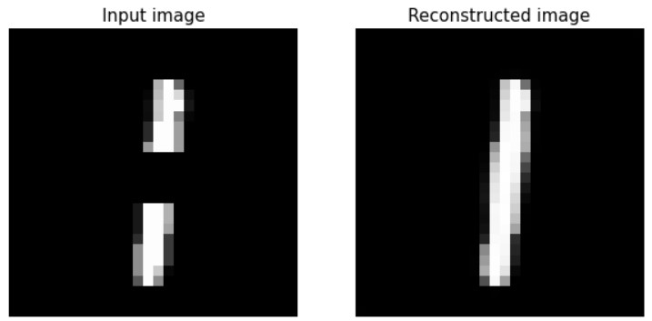

```python
train_an = train.copy()
train_an[:, 12:17, 12:17].fill(0)
```

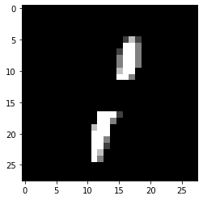

```python
plt.imshow(train_an[1].reshape(28,28), 'gray')
```

```python
train_an = train_an.reshape(3000, 28, 28, 1)
train = train.reshape(3000, 28, 28, 1)
```

```python
inputs = tf.keras.Input(shape = (28, 28, 1))

block1 = tf.keras.layers.Conv2D(filters = 32,
                           kernel_size = (3,3),
                           activation = 'relu',
                           padding = 'SAME')(inputs)

x = tf.keras.layers.MaxPool2D(2)(block1)

block2 = tf.keras.layers.Conv2D(filters = 64,
                           kernel_size = (3,3),
                           activation = 'relu',
                           padding = 'SAME')(x)

x = tf.keras.layers.MaxPool2D(2)(block2)

x = tf.keras.layers.Conv2D(filters = 128,
                           kernel_size = (3,3),
                           activation = 'relu',
                           padding = 'SAME')(x)

x = tf.keras.layers.Conv2DTranspose(64,
                                    kernel_size = 2,
                                    strides = 2)(x)
x = tf.keras.layers.Concatenate()([block2, x])

x = tf.keras.layers.Conv2D(filters = 64,
                           kernel_size = (3,3),
                           activation = 'relu',
                           padding = 'SAME')(x)

x = tf.keras.layers.Conv2DTranspose(32,
                                    kernel_size = 2,
                                    strides = 2)(x)

x = tf.keras.layers.Concatenate()([block1, x])

x = tf.keras.layers.Conv2D(filters = 32,
                           kernel_size = (3,3),
                           activation = 'relu',
                           padding = 'SAME')(x)

outputs = tf.keras.layers.Conv2D(filters = 1,
                                 kernel_size = (3,3),
                                 padding = 'SAME',
                                 activation = 'sigmoid')(x)

model3 = tf.keras.Model(inputs, outputs)

model3.compile(optimizer = 'adam',
               loss = 'binary_crossentropy')

model3.fit(train_an, train, batch_size = 16, epochs = 5)
```

```
<keras.callbacks.History at 0x22fbe8b6b38>
```

```python
newt = np.zeros((1000, 28, 28))

for i in range(0, 1000):
    new = model3.predict(test3[[i]])
    newt[i] = new.reshape(28,28)
    i = i + 1
```

### (4) Perform the anomaly test on the fixed dataset

```python
RRtest3 = []
for kk in range(1000):
    img = newt[kk].reshape(-1, 28, 28, 1)
    RRtest3.append(model.evaluate(img, img, verbose = 0))

RRt3 = np.mean(RRtest3)
print('Reconstruciton error of the fixed test dataset 3: ', RRt3)
```

```
Reconstruciton error of the fixed test dataset 3:  0.009302247520769014
```

# Problem 2: Self-supervised Learning

In PS#15, you have written about pretext tasks you can implement for the self-supervised learning. In this problem, you will going to use pretext tasks other than Rotation Network to perform MNIST image classification. There is no specific conditions that you need to follow. Your goal is reach 80% accuracy in the downstream task.

- Pretext Task: any pretext tasks other than Rotation Network
- Downstream Task: MNIST image classification

### (1) Build a model for the pretext task

- You may use any kind of dataset for the pretext task, but I recommend you to use MNIST dataset.

In fact, you have already built the network to perform the pretext task in problem 1. Think carefully about the FCN structure in the first problem.

```python
train = np.load('./data_files/AD train data.npy')
train_an = train.copy()
train_an[:, 12:17, 12:17].fill(0)
```

```python
train_an = train_an.reshape(3000, 28, 28, 1)
train = train.reshape(3000, 28, 28, 1)
```

```python
inputs = tf.keras.Input(shape = (28, 28, 1))

block1 = tf.keras.layers.Conv2D(filters = 32,
                           kernel_size = (3,3),
                           activation = 'relu',
                           padding = 'SAME')(inputs)

x = tf.keras.layers.MaxPool2D(2)(block1)

block2 = tf.keras.layers.Conv2D(filters = 64,
                           kernel_size = (3,3),
                           activation = 'relu',
                           padding = 'SAME')(x)

x = tf.keras.layers.MaxPool2D(2)(block2)

x = tf.keras.layers.Conv2D(filters = 128,
                           kernel_size = (3,3),
                           activation = 'relu',
                           padding = 'SAME')(x)

x = tf.keras.layers.Conv2DTranspose(64,
                                    kernel_size = 2,
                                    strides = 2)(x)

x = tf.keras.layers.Concatenate()([block2, x])

x = tf.keras.layers.Conv2D(filters = 64,
                           kernel_size = (3,3),
                           activation = 'relu',
                           padding = 'SAME')(x)

x = tf.keras.layers.Conv2DTranspose(32,
                                    kernel_size = 2,
                                    strides = 2)(x)

x = tf.keras.layers.Concatenate()([block1, x])

x = tf.keras.layers.Conv2D(filters = 32,
                           kernel_size = (3,3),
                           activation = 'relu',
                           padding = 'SAME')(x)

outputs = tf.keras.layers.Conv2D(filters = 1,
                                 kernel_size = (3,3),
                                 padding = 'SAME',
                                 activation = 'sigmoid')(x)

model4 = tf.keras.Model(inputs, outputs)

model4.compile(optimizer = 'adam',
               loss ='binary_crossentropy')

model4.fit(train_an, train, batch_size = 16, epochs = 5)
```

```
<keras.callbacks.History at 0x22fbe88c940>
```

```python
model4.trainable = False
```

### (2) Build a model for the downstream task (MNIST Image Classification)

- Use 1000 randomly selected MNIST images as training dataset
- The final Dense layer should be the only layer that is trainable.
- Do not use more than 50 epochs

```python
(X_train, Y_train), (X_test, Y_test) = tf.keras.datasets.mnist.load_data()
X_train = X_train[:1000]
Y_train = Y_train[:1000]
X_test = X_test[:300]
Y_test = Y_test[:300]
```

```python
X_train = X_train.reshape(1000, 28, 28, 1)
Y_train = tf.one_hot(Y_train, 10, on_value = 1.0, off_value = 0.0)
```

```python
model_downstream = tf.keras.models.Sequential([
    model4.get_layer(index = 0),
    model4.get_layer(index = 1),
    model4.get_layer(index = 2),
    model4.get_layer(index = 3),
    model4.get_layer(index = 4),
    model4.get_layer(index = 5),
    tf.keras.layers.Flatten(),
    tf.keras.layers.Dense(units = 10, activation = 'softmax')
])

model_downstream.summary()
```

```
Model: "sequential_2"
_________________________________________________________________
Layer (type)                 Output Shape              Param #
=================================================================
conv2d_9 (Conv2D)            (None, 28, 28, 32)        320
_________________________________________________________________
max_pooling2d_2 (MaxPooling2 (None, 14, 14, 32)        0
_________________________________________________________________
conv2d_10 (Conv2D)           (None, 14, 14, 64)        18496
_________________________________________________________________
max_pooling2d_3 (MaxPooling2 (None, 7, 7, 64)          0
_________________________________________________________________
conv2d_11 (Conv2D)           (None, 7, 7, 128)         73856
_________________________________________________________________
flatten (Flatten)            (None, 6272)              0
_________________________________________________________________
dense (Dense)                (None, 10)                62730
=================================================================
Total params: 155,402
Trainable params: 62,730
Non-trainable params: 92,672
_________________________________________________________________
```

```python
model_downstream.compile(optimizer = tf.keras.optimizers.SGD(learning_rate = 0.001,momentum = 0.9),
                         loss = 'categorical_crossentropy',
                         metrics = 'accuracy')

model_downstream.fit(X_train,
                     Y_train,
                     batch_size = 64,
                     validation_split = 0.2,
                     epochs = 50,
                     verbose = 2)
```

```
13/13 - 0s - loss: 901.9641 - accuracy: 0.2612 - val_loss: 858.6612 - val_accuracy: 0.3900
13/13 - 0s - loss: 410.1766 - accuracy: 0.6587 - val_loss: 447.4544 - val_accuracy: 0.6000
13/13 - 0s - loss: 207.3341 - accuracy: 0.8000 - val_loss: 174.2985 - val_accuracy: 0.8100
13/13 - 0s - loss: 114.8412 - accuracy: 0.8600 - val_loss: 152.6208 - val_accuracy: 0.8200
13/13 - 0s - loss: 69.3400 - accuracy: 0.9125 - val_loss: 151.2034 - val_accuracy: 0.8500
13/13 - 0s - loss: 54.8383 - accuracy: 0.9187 - val_loss: 145.7267 - val_accuracy: 0.8500
13/13 - 0s - loss: 52.8800 - accuracy: 0.9087 - val_loss: 147.6323 - val_accuracy: 0.8300
13/13 - 0s - loss: 38.0468 - accuracy: 0.9237 - val_loss: 115.9792 - val_accuracy: 0.8500
13/13 - 0s - loss: 35.2858 - accuracy: 0.9375 - val_loss: 113.1595 - val_accuracy: 0.8800
13/13 - 0s - loss: 25.7972 - accuracy: 0.9388 - val_loss: 117.9516 - val_accuracy: 0.8800
13/13 - 0s - loss: 27.5229 - accuracy: 0.9337 - val_loss: 116.4602 - val_accuracy: 0.8650
13/13 - 0s - loss: 24.7372 - accuracy: 0.9488 - val_loss: 119.8096 - val_accuracy: 0.8600
13/13 - 0s - loss: 13.6436 - accuracy: 0.9600 - val_loss: 104.9333 - val_accuracy: 0.8650
13/13 - 0s - loss: 11.9678 - accuracy: 0.9613 - val_loss: 113.3171 - val_accuracy: 0.8500
13/13 - 0s - loss: 11.8522 - accuracy: 0.9663 - val_loss: 106.3839 - val_accuracy: 0.8700
13/13 - 0s - loss: 8.4934 - accuracy: 0.9750 - val_loss: 102.4703 - val_accuracy: 0.8800
13/13 - 0s - loss: 7.9473 - accuracy: 0.9650 - val_loss: 114.1802 - val_accuracy: 0.8700
13/13 - 0s - loss: 8.7311 - accuracy: 0.9650 - val_loss: 108.0180 - val_accuracy: 0.8650
13/13 - 0s - loss: 4.9752 - accuracy: 0.9762 - val_loss: 89.0196 - val_accuracy: 0.8850
13/13 - 0s - loss: 4.3150 - accuracy: 0.9837 - val_loss: 86.7143 - val_accuracy: 0.8900
13/13 - 0s - loss: 5.1771 - accuracy: 0.9750 - val_loss: 99.4654 - val_accuracy: 0.8700
13/13 - 0s - loss: 5.6327 - accuracy: 0.9650 - val_loss: 108.2883 - val_accuracy: 0.8600
13/13 - 0s - loss: 4.1400 - accuracy: 0.9737 - val_loss: 95.1864 - val_accuracy: 0.8600
13/13 - 0s - loss: 4.3873 - accuracy: 0.9737 - val_loss: 86.9568 - val_accuracy: 0.8850
13/13 - 0s - loss: 5.4181 - accuracy: 0.9787 - val_loss: 101.5169 - val_accuracy: 0.8500
13/13 - 0s - loss: 2.9174 - accuracy: 0.9800 - val_loss: 87.4097 - val_accuracy: 0.8650
13/13 - 0s - loss: 2.8762 - accuracy: 0.9837 - val_loss: 102.1180 - val_accuracy: 0.8650
13/13 - 0s - loss: 1.8766 - accuracy: 0.9875 - val_loss: 100.0967 - val_accuracy: 0.8550
13/13 - 0s - loss: 3.7585 - accuracy: 0.9837 - val_loss: 95.4219 - val_accuracy: 0.8850
13/13 - 0s - loss: 2.6839 - accuracy: 0.9800 - val_loss: 93.9469 - val_accuracy: 0.8650
13/13 - 0s - loss: 3.5559 - accuracy: 0.9812 - val_loss: 88.7971 - val_accuracy: 0.8650
13/13 - 0s - loss: 0.8392 - accuracy: 0.9900 - val_loss: 83.4597 - val_accuracy: 0.8900
13/13 - 0s - loss: 0.4951 - accuracy: 0.9962 - val_loss: 82.8808 - val_accuracy: 0.8850
13/13 - 0s - loss: 7.4506e-10 - accuracy: 1.0000 - val_loss: 83.5322 - val_accuracy: 0.8950
13/13 - 0s - loss: 0.1337 - accuracy: 0.9975 - val_loss: 85.4365 - val_accuracy: 0.8950
13/13 - 0s - loss: 0.0605 - accuracy: 0.9975 - val_loss: 89.1300 - val_accuracy: 0.8800
13/13 - 0s - loss: 0.8495 - accuracy: 0.9912 - val_loss: 93.8405 - val_accuracy: 0.8900
13/13 - 0s - loss: 0.6527 - accuracy: 0.9950 - val_loss: 94.2656 - val_accuracy: 0.8700
13/13 - 0s - loss: 0.2227 - accuracy: 0.9937 - val_loss: 88.2612 - val_accuracy: 0.8800
13/13 - 0s - loss: 0.7094 - accuracy: 0.9937 - val_loss: 90.6618 - val_accuracy: 0.8900
13/13 - 0s - loss: 0.3354 - accuracy: 0.9962 - val_loss: 88.2616 - val_accuracy: 0.9000
13/13 - 0s - loss: 0.3973 - accuracy: 0.9962 - val_loss: 83.4165 - val_accuracy: 0.8900
13/13 - 0s - loss: 1.1474e-08 - accuracy: 1.0000 - val_loss: 92.5234 - val_accuracy: 0.8800
13/13 - 0s - loss: 0.3859 - accuracy: 0.9962 - val_loss: 87.6248 - val_accuracy: 0.8900
13/13 - 0s - loss: 0.0910 - accuracy: 0.9975 - val_loss: 91.5006 - val_accuracy: 0.8650
13/13 - 0s - loss: 0.2654 - accuracy: 0.9962 - val_loss: 87.8437 - val_accuracy: 0.8800
13/13 - 0s - loss: 0.5150 - accuracy: 0.9950 - val_loss: 92.5504 - val_accuracy: 0.8700
13/13 - 0s - loss: 0.1935 - accuracy: 0.9987 - val_loss: 87.3727 - val_accuracy: 0.8750
13/13 - 0s - loss: 0.0000e+00 - accuracy: 1.0000 - val_loss: 85.7810 - val_accuracy: 0.8800
13/13 - 0s - loss: 0.0000e+00 - accuracy: 1.0000 - val_loss: 85.7388 - val_accuracy: 0.8800
```

```
<keras.callbacks.History at 0x22fc255b8d0>
```

### (3) Show your model's classification accuracy on the test dataset

```python
X_test = X_test.reshape(-1, 28, 28, 1)
Y_test = tf.one_hot(Y_test, 10, on_value = 1.0, off_value = 0.0)
test_self = model_downstream.evaluate(X_test, Y_test, batch_size = 64, verbose = 2)

print("")
print('Self-supervised Learning Accuracy on Test Data:  {:.2f}%'.format(test_self[1] * 100))
```

```
5/5 - 0s - loss: 36.4436 - accuracy: 0.9233

Self-supervised Learning Accuracy on Test Data:  92.33%
```

# Problem 3: GCN

As you know, MLP uses the features of the given data to predict the class of each data. However, it cannot effectively model the conectivity among data. Therefore, in this problem we will compare the performance of MLP and GCN for a dataset with a graph stucture.

Given dataset is the Pubmed citation data. PubMed is a free search engine accessing primarily the MEDLINE database of references and abstracts on life sciences and biomedical topics. Basically, Pubmed data is very similar to the 'Cora' dataset that we have practiced during the class. Visit https://graphneural.network/datasets/ and https://en.wikipedia.org/wiki/PubMed to fully understand the given data.

- The Pubmed dataset consists of 19717 nodes classified into one of three classes.
- The citation network consists of 108365 links.
- Each publication in the dataset is described by a TF/IDF weighted word vector indicating the absence/presence of the corresponding word from the dictionary which consists of 500 unique words.

### (0) Prerequisite

```python
# !pip install spektral
# !pip install scipy==1.8.0
```

```python
import numpy as np
import tensorflow as tf

from tensorflow.keras.layers import Dropout, Input
from tensorflow.keras.losses import CategoricalCrossentropy
from tensorflow.keras.optimizers import Adam

from spektral.datasets.citation import Citation
from spektral.layers import GCNConv
from spektral.transforms import LayerPreprocess
```

```python
learning_rate = 1e-2
seed = 0
epochs = 100
data = "pubmed"

tf.random.set_seed(seed = seed)  # Make weight initialization reproducible

# Load data
dataset = Citation(data, normalize_x = True)
```

```
Pre-processing node features
```

### (1) Data generation

```python
data = dataset[0]
x_data, y_data = data.x, data.y

train_mask, val_mask, test_mask = dataset.mask_tr, dataset.mask_va, dataset.mask_te

# Train / Validation data generation

x_train = x_data[train_mask]
y_train = y_data[train_mask]
x_val = x_data[val_mask]
y_val = y_data[val_mask]
```

```python
N = dataset.n_nodes  # Number of nodes in the graph
F = dataset.n_node_features  # Original size of node features
n_out = dataset.n_labels  # labels are sparse indices
```

### (2) Build MLP model

Build the MLP classifier with 500 features, but no citation links.

- Two dense layers
- The hidden layer has 8 units and uses 'relu' activation
- The last dense layer has 'softmax' activation
- Use adam optimizer with learning rate of 0.01 and BinaryCrossentropy for the loss
- Use 100 epochs

```python
MLP_model = tf.keras.models.Sequential([
    tf.keras.layers.Dense(units = 8, activation = 'relu', input_shape = (F, )),
    tf.keras.layers.Dense(units = n_out, activation = 'softmax')
])

MLP_model.compile(optimizer = tf.keras.optimizers.Adam(0.01),
                  loss = tf.keras.losses.BinaryCrossentropy(),
                  weighted_metrics = ['acc'])

MLP_model.summary()
```

```
Model: "sequential_3"
_________________________________________________________________
Layer (type)                 Output Shape              Param #
=================================================================
dense_1 (Dense)              (None, 8)                 4008
_________________________________________________________________
dense_2 (Dense)              (None, 3)                 27
=================================================================
Total params: 4,035
Trainable params: 4,035
Non-trainable params: 0
_________________________________________________________________
```

```python
hist1 = MLP_model.fit(x = x_train,
                      y = y_train,
                      validation_data = (x_val, y_val),
                      epochs = epochs)
```

### (3) Build GCN model

Build the GCN node classifier using citation links in addition to the 500 features.

- The number of channels in GCN layers is 8
- Dropout rate is 0.6
- Use 100 epochs only
- In the first GCN layer, use 'relu' activation
- In the second GCN layer, use 'softmax' activation
- Use two GCN layers only
- Use 'adam' optimizer with learning rate of 0.01 and CategoricalCrossentropy

```python
# Parameters
channels = 8  # Number of channels in the first GCN layer
dropout = 0.6  # Dropout rate for the features and adjacency matrix
epochs = 100  # Number of training epochs
seed = 0
data = "pubmed"

tf.random.set_seed(seed=seed)  # make weight initialization reproducible
```

```python
# Load data
dataset = Citation(data, normalize_x = True, transforms = [LayerPreprocess(GCNConv)])

graph = dataset[0]
H, A, labels_encoded = graph.x, graph.a, graph.y
```

```
Pre-processing node features
```

```python
#  Generate mask for train / validation / test
train_mask, val_mask, test_mask = dataset.mask_tr, dataset.mask_va, dataset.mask_te
```

```python
N = dataset.n_nodes  # Number of nodes in the graph
F = dataset.n_node_features  # Original size of node features
n_out = dataset.n_labels  # Number of classes
```

```python
# Model definition
x_in = Input(shape = (F,))
a_in = Input((N,), sparse = True)

do_1 = Dropout(dropout)(x_in)
gc_1 = GCNConv(channels,
               dropout_rate = dropout,
               activation = "relu")([do_1, a_in])

do_2 = Dropout(dropout)(gc_1)
gc_2 = GCNConv(n_out,
               dropout_rate = dropout,
               activation = "softmax")([do_2, a_in])

# Build model
model = tf.keras.Model(inputs = [x_in, a_in], outputs = gc_2)
optimizer = Adam(lr = learning_rate)

model.compile(optimizer = optimizer,
              loss = tf.keras.losses.CategoricalCrossentropy(reduction = "sum"),
              weighted_metrics = ["acc"])
model.summary()
```

```
Model: "model_3"
__________________________________________________________________________________________________
Layer (type)                    Output Shape         Param #     Connected to
==================================================================================================
input_3 (InputLayer)            [(None, 500)]        0
__________________________________________________________________________________________________
dropout (Dropout)               (None, 500)          0           input_3[0][0]
__________________________________________________________________________________________________
input_4 (InputLayer)            [(None, 19717)]      0
__________________________________________________________________________________________________
gcn_conv (GCNConv)              (None, 8)            4008        dropout[0][0]
                                                                 input_4[0][0]
__________________________________________________________________________________________________
dropout_1 (Dropout)             (None, 8)            0           gcn_conv[0][0]
__________________________________________________________________________________________________
gcn_conv_1 (GCNConv)            (None, 3)            27          dropout_1[0][0]
                                                                 input_4[0][0]
==================================================================================================
Total params: 4,035
Trainable params: 4,035
Non-trainable params: 0
__________________________________________________________________________________________________
```

```python
hist2 = model.fit(x = [H, A],
                  y = labels_encoded,
                  validation_data = ([H, A], labels_encoded),
                  sample_weight = train_mask,
                  epochs = epochs,
                  batch_size = N,
                  shuffle = False)
```

### (4) Plot the result (code is given for you)

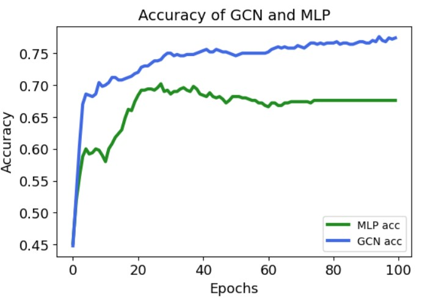

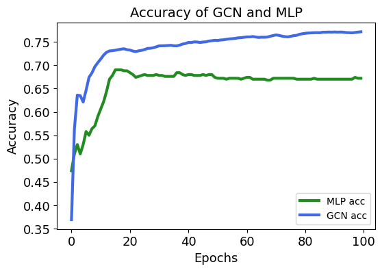

```python
import matplotlib.pyplot as plt

fig = plt.figure(dpi = 100)

plt.plot(hist1.history['val_acc'], 'forestgreen', linewidth = 3, label = 'MLP acc')
plt.plot(hist2.history['val_acc'], 'royalblue', linewidth = 3, label = 'GCN acc')
plt.title('Accuracy of GCN and MLP', fontsize = 14)
plt.xticks(fontsize = 13)
plt.yticks(fontsize = 13)
plt.xlabel('Epochs', fontsize = 13)
plt.ylabel('Accuracy', fontsize = 13)
plt.legend(loc = 'best')

plt.show()
```